# SummativeAssessment

Kexin Wu

23/12/2021

```r
library(tidyverse)
```

## Section A (30 marks)

In this part of your assessment you will perform a data wrangling task with some finance data.

Note that clarity is highly important. Be careful to make sure you clearly explain each step in your answer. You should also include comments within your code. In addition, make the structure of your answer clear through the use of headings. You should also make sure your code is clean by making careful use of Tidyverse methods.*

### A.1

Begin by downloading the csv file available within the Assessment section within Blackboard entitled “finance_data_EMATM0061”.

**(Q)** Next load the “finance_data_EMATM0061” csv file into R data frame called “finance_data_original”.

**(A)**

```r
folder_name <- "/Users/wukexin/Desktop/SCEM/final_assessment"
file_name <- "finance_data_EMATM0061"

finance_data_original <- read.csv(paste0(folder_name, "/", file_name, ".csv"))
```

**(Q)** How many rows and how many columns does this data frame have?

**(A)**

```r
finance_data_original %>% nrow()
```

```
## [1] 1051
```

```r
finance_data_original %>% ncol()
```

```
## [1] 30
```

The finance_data_original has 1051 rows and 30 columns.

### A.2

**(Q)** Generate a new data frame called “finance_data” which is a subset of the “finance_data_original” data frame with the same number of rows, but only six columns:

- The first column should be called “state_year_code” and correspond to the “state_year_code” column in the csv.
- The second column should be called “education_expenditure” and should correspond to the “Details.Education.Education.Total” column in the csv.
- The third column should be called “health_expenditure” and should correspond to the “Details.Health.Health.Total.Expenditure” column in the csv.
- The fourth column should be called “transport_expenditure” and should correspond to the “Details.Transportation.Highways.Highways.Total.Expenditure” column in the csv.
- The fifth column should be called “totals_revenue” and should correspond to the “Totals.Revenue” column in the csv.
- The sixth column should be called “totals_expenditure” and should correspond to the “Totals.Expenditure” column in the csv.

**(A)**

```r
finance_data <- finance_data_original %>%
  select(state_year_code = state_year_code,
         education_expenditure = Details.Education.Education.Total,
         health_expenditure = Details.Health.Health.Total.Expenditure,
         transport_expenditure = Details.Transportation.Highways.Highways.Total.Expenditure,
         totals_revenue = Totals.Revenue,
         totals_expenditure = Totals.Expenditure)
```

**(Q)** Display a subset of the “finance_data” dataframe consisting of the first five rows and first three columns (“state_year_code”,“education_expenditure”,“health_expenditure”).

**(A)**

```r
finance_data %>% head(5)
```

```
##   state_year_code education_expenditure health_expenditure
## 1   ALABAMA__1992               3570524                 NA
## 2   ALABAMA__1993               3663465                 NA
## 3   ALABAMA__1994               3969277             487044
## 4   ALABAMA__1995               4400912             491648
## 5   ALABAMA__1996               4872259             514380
##   transport_expenditure totals_revenue totals_expenditure
## 1                694874       10536166            9650515
## 2                856228       11389335           10242374
## 3                883852       11599362           10815221
## 4                924411             NA           11541881
## 5                881381       12741148                 NA
```

### A.3

**(Q)** Create a new column within the “finance_data” data frame called “totals_savings” which is equal to the difference between revenue and the expenditure ie. the elements of the “totals_savings” column are equal to elements within the “totals_revenue” minus the element within the “totals_expenditure” column, for each row.

Your “finance_data” data frame should now have seven columns.

**(A)**

```r
finance_data <- finance_data %>%
  mutate(totals_savings = totals_revenue - totals_expenditure)
finance_data %>% ncol()
```

```
## [1] 7
```

**(Q)** Display a subset of the “finance_data” dataframe consisting of the first three rows and the four columns “state_year_code”,“totals_revenue”,“totals_expenditure”,“totals_savings”.

**(A)**

```r
finance_data %>%
  select(state_year_code, totals_revenue, totals_expenditure, totals_savings) %>%
  head(3)
```

```
##   state_year_code totals_revenue totals_expenditure totals_savings
## 1   ALABAMA__1992       10536166            9650515         885651
## 2   ALABAMA__1993       11389335           10242374        1146961
## 3   ALABAMA__1994       11599362           10815221         784141
```

### A.4

**(Q)** The “state_year_code” column within your “finance_data” data frame contains both a state and a year in character format connected via a double underscore.

Divide the “state_year_code” column into two separate columns, a “state” column and a “year” column which replace the original “state_year_code” column.

Your “finance_data” data frame should now have eight columns.

**(A)**

```r
finance_data <- finance_data %>%
  separate(state_year_code, into = c("state", "year"), sep = "__", convert =TRUE)

finance_data %>% ncol()
```

```
## [1] 8
```

```r
finance_data %>% head(5)
```

```
##     state year education_expenditure health_expenditure transport_expenditure
## 1 ALABAMA 1992               3570524                 NA                694874
## 2 ALABAMA 1993               3663465                 NA                856228
## 3 ALABAMA 1994               3969277             487044                883852
## 4 ALABAMA 1995               4400912             491648                924411
## 5 ALABAMA 1996               4872259             514380                881381
##   totals_revenue totals_expenditure totals_savings
## 1       10536166            9650515         885651
## 2       11389335           10242374        1146961
## 3       11599362           10815221         784141
## 4             NA           11541881             NA
## 5       12741148                 NA             NA
```

**(Q)** Convert the states so that they appear with the first letter of each word in upper case and the remainder in lower case eg. we should see “New Hampshire” rather than “NEW HAMPSHIRE”. You may wish to use the function str_to_title().

**(A)**

```r
finance_data <- finance_data %>%
  mutate(state_title = str_to_title(state)) %>%
  select(-state) %>%
  rename(state = state_title)
```

**(Q)** Display a subset of the “finance_data” data frame consisting of the first three rows and the five columns “state”, “year”,“totals_revenue”,“totals_expenditure”,“totals_savings”.

**(A)**

```r
finance_data %>%
  select(state, year, totals_revenue, totals_expenditure, totals_savings) %>%
  head(3)
```

```
##     state year totals_revenue totals_expenditure totals_savings
## 1 Alabama 1992       10536166            9650515         885651
## 2 Alabama 1993       11389335           10242374        1146961
## 3 Alabama 1994       11599362           10815221         784141
```

### A.5

**(Q)** Generate a plot which displays the total revenue (“total_revenue”) as function of the year (“year”) for the following four states: Louisiana, Montana, Mississippi and Kentucky.

Display the revenue in terms of millions of dollars.

**(A)**

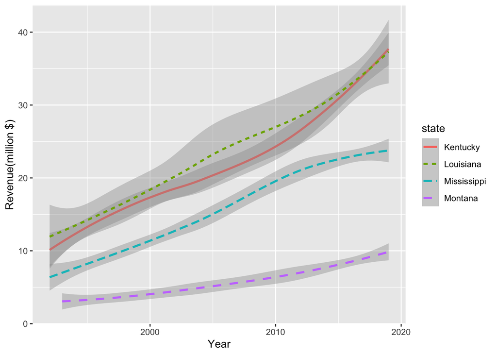

```r
finance_data %>%
  filter(state %in% c("Louisiana", "Montana", "Mississippi", "Kentucky")) %>%
  ggplot(aes(x = year, y = totals_revenue / 1000000, color = state,
                         linetype = state)) +
  geom_smooth() + xlab("Year") + ylab("Revenue(million $)")
```

### A.6

**(Q)** Create a function called get_decade() which takes as input a number and rounds that number down to the nearest multiple of 10. For example, the numbers 20, 21, 22, . . . , 29 would all be mapped to the output 20.

**(A)**

```r
get_decade <- function(x){
  return((x %/% 10) * 10)
}
```

**(Q)** Use your get_decade() function to add a new column to the “finance_data” data frame called “decade” which should give the decade corresponding to the year column. For example, the decade of the years 1990,1991,. . . ,1998,1999 is 1990.

Your “finance_data” data frame should now have nine columns.

**(A)**

```r
finance_data <- finance_data %>%
  mutate(decade = map_dbl(year, get_decade))

finance_data %>% ncol()
```

```
## [1] 9
```

**(Q)** Which three states had the highest mean-average savings (“totals_savings”) over the decade starting 2000?

Note:

- When computing the average you should disregard any years in which the information is not available i.e. the average should be taken only over those years for which the savings entry is not an “NA”.
- You should aim to use a succinct Tidyverse type solution.

**(A)**

```r
finance_data %>%
  select(state, decade, totals_savings) %>%
  group_by(state, decade) %>%
  summarise(average_savings = mean(totals_savings, na.rm = TRUE)) %>%
  filter(decade == 2000) %>%
  arrange(desc(average_savings)) %>%
  head(3)
```

```
## # A tibble: 3 × 3
## # Groups:   state [3]
##   state      decade average_savings
##   <chr>       <dbl>           <dbl>
## 1 Texas        2000        4103352.
## 2 Ohio         2000        3025980
## 3 California   2000        2510483.
```

The highest mean_average sacings(“totals_savings”) over the decade starting 2000 are Texas, Ohio and California.

### A.7

**(Q)** Next generate a summary data frame from the “finance_data” data frame called “alaska_summary” with the following properties:

Your summary data frame should correspond to rows associated with the state of Alaska. Your summary data frame should have three rows each corresponding to a decade from 1990 through to 2010 inclusive. Your data frame should also have seven columns:

(a) “decade” – the decade (1990, 2000, 2010)

(b) “ed_mn” – the mean of the education expenditure in Alaska for the corresponding decade

(c) “ed_md” – the median of the education expenditure in Alaska for the corresponding decade

(d) “he_mn” – the mean of the health expenditure in Alaska for the corresponding decade

(e) “he_md” – the median of the health expenditure in Alaska for the corresponding decade

(f) “tr_mn” – the mean of the transport expenditure in Alaska for the corresponding decade

(g) “tr_md” – the median of the transport expenditure in Alaska for the corresponding decade

You should use Tidyverse methods to create your “alaska_summary” data frame. Display the “alaska_summary” data frame.

**(A)**

```r
alaska_summary <- finance_data %>%
  filter(state == "Alaska") %>%
  group_by(decade) %>%
  summarise(across(starts_with(c("education_expenditure", "health_expenditure", "transport_expenditure")), list(md = median, mn = mean), .names = "{substring(.col, 1, 2)}_{.fn}", na.rm = TRUE))

alaska_summary
```

```
## # A tibble: 3 × 7
##   decade    ed_md    ed_mn   he_md   he_mn    tr_md    tr_mn
##    <dbl>    <dbl>    <dbl>   <dbl>   <dbl>    <dbl>    <dbl>
## 1   1990 1246864. 1246426. 164546. 162785.  582710.  582137.
## 2   2000 1566815  1546233. 160168  152003.  687407   723347.
## 3   2010 2595207  2642603. 278394  274688  1271514  1210822.
```

### A.8

**(Q)** Create a function called impute_by_median which takes as input a vector numerical values, which may include some “NA”s, and replaces any missing values (“NA”s) with the median over the vector.

**(A)**

```r
impute_by_median <- function(x){
  mu = median(x, na.rm = TRUE) # first compute the median of x
  impute_f <- function(z){ # coordinate-wise imputation
    if(is.na(z)){
      return(mu) # if z is na replace with median
    } else{
      return(z) # otherwise leave in place
    }
  }
  return(map_dbl(x, impute_f))
}
```

**(Q)** *Next generate a subset of your “finance_data” data frame called “idaho_2000” which contains all those rows in which the state column takes the value “Idaho” and the “decade” column takes the value “2000” and includes the columns “year”, “education_expenditure”, “health_expenditure”, “transport_expenditure”, “totals_revenue”, “totals_expenditure”, “totals_savings” (i.e. all columns except “state” and “decade”).

**(A)**

```r
idaho_2000 <- finance_data %>%
  filter(state == "Idaho") %>%
  filter(decade == 2000) %>%
  select(year, education_expenditure, health_expenditure, transport_expenditure, totals_revenue, totals_expenditure, totals_savings)

idaho_2000 %>% head(5)
```

```
##   year education_expenditure health_expenditure transport_expenditure
## 1 2000               1663980              98510                470498
## 2 2001               1768837             103705                501659
## 3 2002                    NA                 NA                499916
## 4 2003               1886421             116088                521746
## 5 2004                    NA             131165                524242
##   totals_revenue totals_expenditure totals_savings
## 1        5576284            4492552        1083732
## 2        5286097            4951659         334438
## 3        4487672            5234047        -746375
## 4        5492993                 NA             NA
## 5        7112364            5762624        1349740
```

**(Q)** Now apply your “impute_by_median” data frame to create a new data frame called “idaho_2000_imputed” which is based on your existing “idaho_2000” data frame but with any missing values replaced with the corresponding me- dian value for the that column. That is, for each of the columns “education_expenditure”, “health_expenditure”, “transport_expenditure”, “totals_revenue”, “totals_expenditure”, “totals_savings” any missing values (given by “NA”) are replaced with the median over that column.

Display a subset of your “idaho_2000_imputed” data frame consisting of the first five rows and the four columns “year”, “health_expenditure”, “education_expenditure” and “totals_savings”.

**(A)**

```r
idaho_2000 <- idaho_2000 %>%
  summarise(across(everything(), impute_by_median))

idaho_2000 %>%
  select(year, health_expenditure, education_expenditure, totals_savings) %>%
  head(5)
```

```
##   year health_expenditure education_expenditure totals_savings
## 1 2000            98510.0               1663980        1083732
## 2 2001           103705.0               1768837         334438
## 3 2002           109896.5               1768837        -746375
## 4 2003           116088.0               1886421         709085
## 5 2004           131165.0               1768837        1349740
```